# IODS course project

sandeep

## # About the project

In the first week of the open data science course, I have learnt the following things. * github * Introduction to R * earned data camp certificate

## My github repository

https://github.com/sandeep37/IODS-project

## My learning diary

https://sandeep37.github.io/IODS-project/

# Analysis of student data

### Introduction to the data

I have completed the data wrangling exercise. Hence, data set from the local data folder is used for exploration.

```r
students2014 <- read.csv("data/learning2014.csv")
dim(students2014)
```

```
## [1] 166   7
```

```r
str(students2014)
```

```
## 'data.frame':    166 obs. of  7 variables:
##  $ gender  : Factor w/ 2 levels "F","M": 1 2 1 2 2 1 2 1 2 1 ...
##  $ Age     : int  53 55 49 53 49 38 50 37 37 42 ...
##  $ attitude: num  3.7 3.1 2.5 3.5 3.7 3.8 3.5 2.9 3.8 2.1 ...
##  $ deep    : num  3.58 2.92 3.5 3.5 3.67 ...
##  $ stra    : num  3.38 2.75 3.62 3.12 3.62 ...
##  $ surf    : num  2.58 3.17 2.25 2.25 2.83 ...
##  $ Points  : int  25 12 24 10 22 21 21 31 24 26 ...
```

```r
summary(students2014)
```

```
##  gender       Age           attitude          deep            stra
##  F:110   Min.   :17.00   Min.   :1.400   Min.   :1.583   Min.   :1.250
##  M: 56   1st Qu.:21.00   1st Qu.:2.600   1st Qu.:3.333   1st Qu.:2.625
##          Median :22.00   Median :3.200   Median :3.667   Median :3.188
##          Mean   :25.51   Mean   :3.143   Mean   :3.680   Mean   :3.121
##          3rd Qu.:27.00   3rd Qu.:3.700   3rd Qu.:4.083   3rd Qu.:3.625
##          Max.   :55.00   Max.   :5.000   Max.   :4.917   Max.   :5.000
##       surf           Points
##  Min.   :1.583   Min.   : 7.00
##  1st Qu.:2.417   1st Qu.:19.00
##  Median :2.833   Median :23.00
##  Mean   :2.787   Mean   :22.72
##  3rd Qu.:3.167   3rd Qu.:27.75
##  Max.   :4.333   Max.   :33.00
```

The student data set has 166 observations and 7 variables. These observations correspond to the responses of students in a statistical course. From the summary data, it is evident that female participants were almost double than male participants. The age of the participants varied from 17 to 55. The median age of the participants is 22. The variable ‘Attitude’ is measured in terms of interest in pursuing statistical studies and their confidence in applying various mathematical operations. Deep is a combination of questions which focused on students willingness to understand new concepts and applying the same in various applications. Stra focused on evaluating individual study plans and time management. Surf included the questions to understand the factors that could demotivate an individual during the learning process. It also included questions on one’s willingness to explore the concepts beyond the syllabus. Points correspond to the maximum exam points.

### Graphical Overview

We plot the data which helps to understand the data in a easy way.

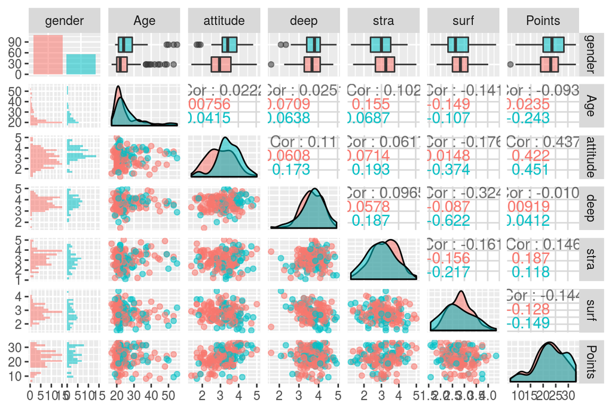

```r
library(ggplot2)
library(GGally)
ggpairs(students2014, mapping = aes(col = gender, alpha = 0.1), lower = list(combo = wrap("facethist", bins = 20)))
```